# A Visual Story of Streaming Advertisements

Haoyuan Liu

## What is this data about?

This visual data story is about streaming advertisements that I recorded through observational logging. Each line in the data is for one ad that I saw on platforms such as YouTube, Instagram, TikTok, web browsers, or other online spaces.

The data consists of the length of each advertisement, the product category of the advertisement, the platform it appeared on, whether the advertisement was skippable, and the date it was recorded. These variables help illustrate how streaming ads vary across platforms and viewing situations.

## Where were the advertisements recorded?

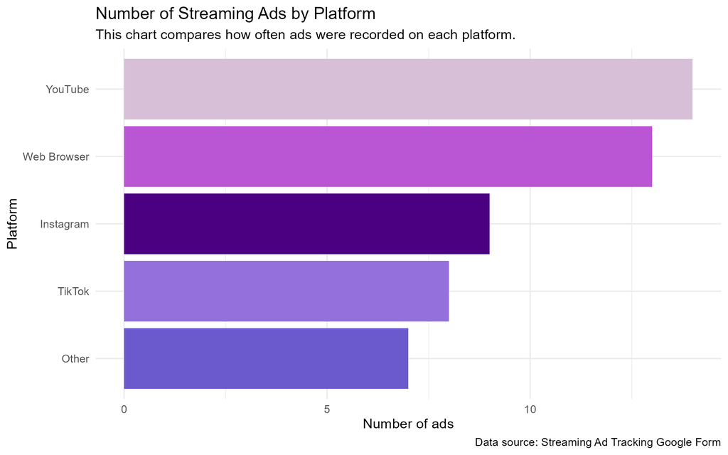

A horizontal bar chart showing the number of streaming advertisements recorded on each platform. The chart compares YouTube, Instagram, TikTok, web browser, and other platforms.

This chart shows the number of advertisements recorded on each platform. Here a bar chart is appropriate, because platform is a categorical variable and the goal is to compare counts across groups.

The visualisation helps to illustrate which platforms were more frequently present in the observation data. This provides a clear starting point for the story, as it details the origin of the advertisements in the dataset.

## Were skippable ads different in length?

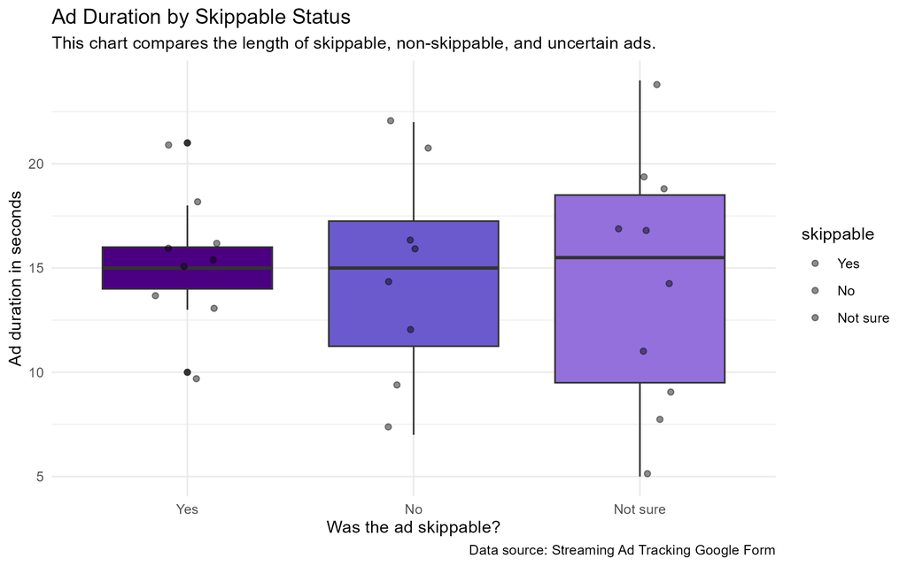

A boxplot with individual points showing advertisement duration by skippable status. The chart compares ads marked as yes, no, and not sure.

This chart compares ads by skippable status and duration. The choice of a boxplot is made because duration is a numerical variable and skippable status is a categorical variable. The individual points were also added so that each recorded ad is still visible.

This visualisation allows the comparison of the spread of advertisement lengths. It indicates whether skippable, non-skippable and uncertain ads were similar in length or whether some groups had more variation.

## When were the advertisements recorded?

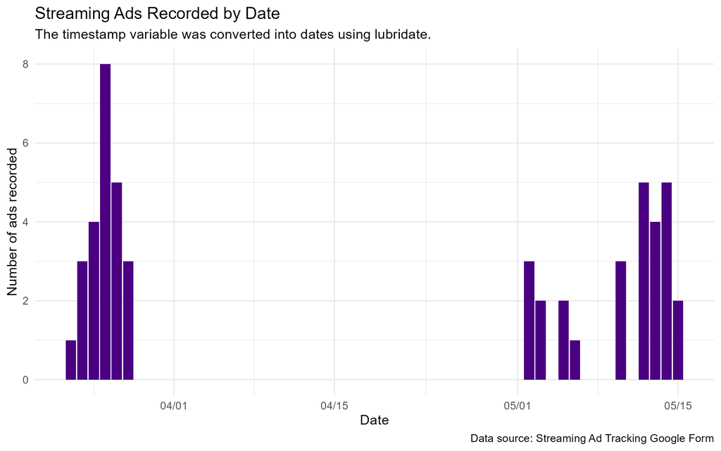

A column chart showing the number of streaming advertisements recorded on each date. The timestamp variable was converted into dates using lubridate.

This chart uses the time stamp from the Google Form responses. The timestamp was converted to date values using the lubridate package, which made it easier to manipulate the time information in a visualisation.

This portion of the story shows the observations were spread out over a collection of dates. So it adds a time-based view to the data rather than simply comparing platforms or advertisement features.

## What does the visual story show?

The three visualisations together show different parts of the streaming advertisement data. The first chart shows the platform, the second chart shows the advertisement duration and skippable status, and the third chart shows the dates of the recorded observations.

The plots and the HTML page use the same purple colour scheme. This makes the story coherent and connects visual design with data visualisations.